# 時間數列分析

Shu Yu Liu

## 資料介紹

分析的資料為台北捷運動物園站2017年1月至2019年12月的日出站人次(資料來源：台北捷運官網)，共1095筆。原始資料的時間數列圖如下：

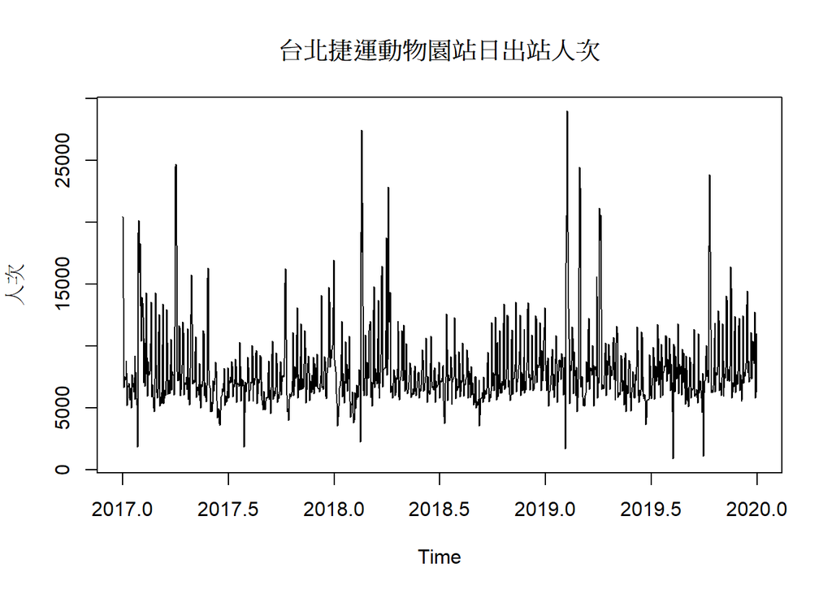

## 配適模型

**Step1**

由於資料在某些時間點變異稍大，決定將資料取對數(以自然數e為底)，取對數後的時間數列圖如下，判斷不需要做進一步的資料轉換。

保留最後的14天資料作為測試集，以其餘資料作為訓練集的SARIMA建模。

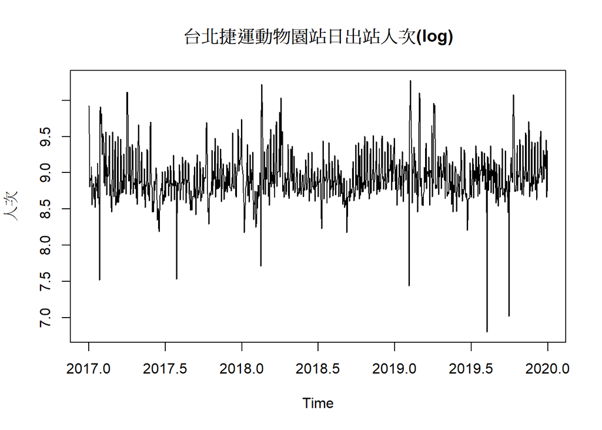

**Step2**

模型：SARIMA(p,d,q)x(P,D,Q)<sub>s</sub> 將訓練集的資料做對數轉換後，畫出其ACF與PACF的圖。

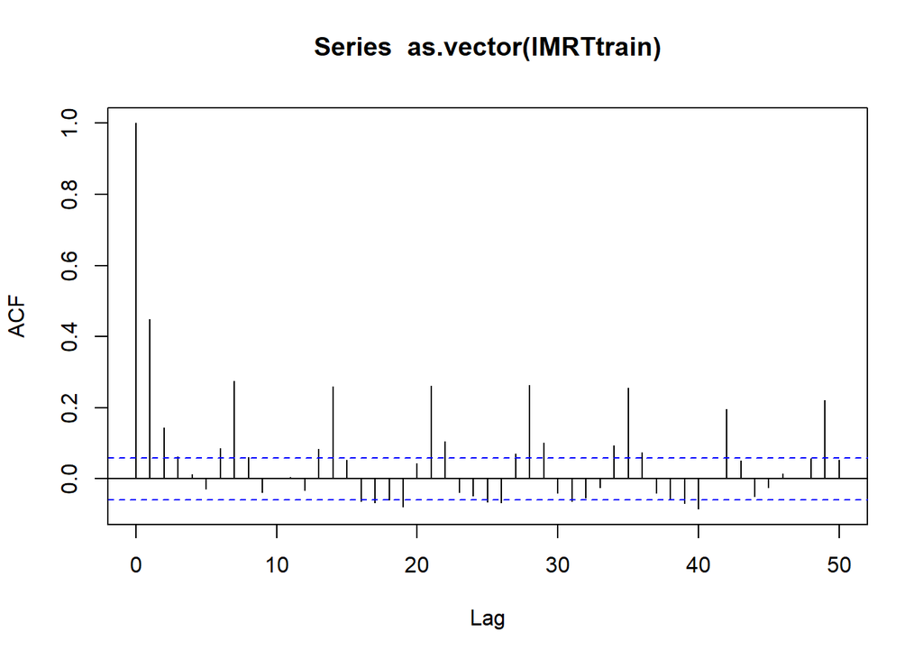

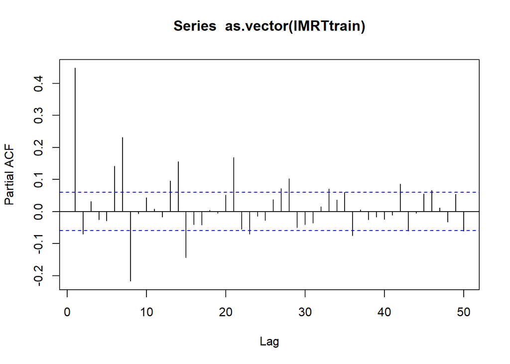

ACF及PACF在lag為7的倍數時較為顯著，因此將季節長度定為7(s = 7)。 觀察圖中季節性(Seasonal)的部分，ACF tails off；PACF tails off，因此SARIMA模型中，選擇季節參數為P = 1, Q = 1。

綜合以上觀察，列舉出以下模型進一步分析。

1. SARIMA(0,0,1)x(1,0,1)<sub>7</sub>
2. SARIMA(0,0,2)x(1,0,1)<sub>7</sub>
3. SARIMA(1,0,0)x(1,0,1)<sub>7</sub>
4. SARIMA(2,0,0)x(1,0,1)<sub>7</sub>
5. SARIMA(1,0,1)x(1,0,1)<sub>7</sub>
6. SARIMA(1,0,2)x(1,0,1)<sub>7</sub>
7. SARIMA(1,0,0)x(2,0,1)<sub>7</sub>
8. SARIMA(1,0,0)x(1,0,2)<sub>7</sub>

**Step3**

對以上八個模型進行參數估計，並且根據參數估計的結果剔除不適合的模型4,5,6,7,8，保留模型1,2,3。

解釋：

模型4中，ar2的係數不顯著(=0)，因此模型中參數p應降為1，變為模型3。

模型5中，ma1的係數不顯著(=0)，因此模型中參數q應改為0，變為模型3。

模型6中，ma2的係數不顯著(=0)，因此模型中參數q應改為1，變為模型5。

模型7中，sar2的係數不顯著(=0)，因此模型中參數P應改為1，變為模型3。

模型8中，sma2的係數不顯著(=0)，因此模型中參數Q應改為1，變為模型3。

```
##
## Call:
## arima(x = lMRTtrain, order = c(0, 0, 1), seasonal = list(order = c(1, 0, 1),
##     period = 7))
##
## Coefficients:
##          ma1    sar1     sma1  intercept
##       0.4548  0.9989  -0.9716     8.9395
## s.e.  0.0231  0.0010   0.0123     0.0840
##
## sigma^2 estimated as 0.06641:  log likelihood = -75.05,  aic = 160.11
```

```
##
## Call:
## arima(x = lMRTtrain, order = c(0, 0, 2), seasonal = list(order = c(1, 0, 1),
##     period = 7))
##
## Coefficients:
##          ma1     ma2    sar1     sma1  intercept
##       0.5247  0.2153  0.9992  -0.9730     8.9323
## s.e.  0.0293  0.0276  0.0008   0.0111     0.1074
##
## sigma^2 estimated as 0.06294:  log likelihood = -46.77,  aic = 105.54
```

```
##
## Call:
## arima(x = lMRTtrain, order = c(1, 0, 0), seasonal = list(order = c(1, 0, 1),
##     period = 7))
##
## Coefficients:
##          ar1    sar1     sma1  intercept
##       0.5353  0.9992  -0.9730     8.9399
## s.e.  0.0258  0.0007   0.0105     0.1365
##
## sigma^2 estimated as 0.06186:  log likelihood = -37.73,  aic = 85.46
```

```
##
## Call:
## arima(x = lMRTtrain, order = c(2, 0, 0), seasonal = list(order = c(1, 0, 1),
##     period = 7))
##
## Coefficients:
##          ar1      ar2    sar1     sma1  intercept
##       0.5394  -0.0076  0.9992  -0.9731     8.9432
## s.e.  0.0304   0.0305  0.0007   0.0105     0.1353
##
## sigma^2 estimated as 0.06186:  log likelihood = -37.7,  aic = 87.39
```

```
##
## Call:
## arima(x = lMRTtrain, order = c(1, 0, 1), seasonal = list(order = c(1, 0, 1),
##     period = 7))
##
## Coefficients:
##          ar1     ma1    sar1     sma1  intercept
##       0.5245  0.0153  0.9992  -0.9731     8.9394
## s.e.  0.0489  0.0573  0.0007   0.0105     0.1354
##
## sigma^2 estimated as 0.06186:  log likelihood = -37.7,  aic = 87.39
```

```
##
## Call:
## arima(x = lMRTtrain, order = c(1, 0, 2), seasonal = list(order = c(1, 0, 1),
##     period = 7))
##
## Coefficients:
##          ar1     ma1      ma2    sar1     sma1  intercept
##       0.5343  0.0050  -0.0066  0.9992  -0.9730     8.9696
## s.e.  0.0963  0.1017   0.0610  0.0007   0.0105     0.1368
##
## sigma^2 estimated as 0.06186:  log likelihood = -37.71,  aic = 89.42
```

```
##
## Call:
## arima(x = lMRTtrain, order = c(1, 0, 0), seasonal = list(order = c(2, 0, 1),
##     period = 7))
##
## Coefficients:
##          ar1    sar1     sar2     sma1  intercept
##       0.5339  1.0562  -0.0567  -0.9774     8.9401
## s.e.  0.0258  0.0317   0.0316   0.0097     0.1349
##
## sigma^2 estimated as 0.06166:  log likelihood = -36.11,  aic = 84.23
```

```
##
## Call:
## arima(x = lMRTtrain, order = c(1, 0, 0), seasonal = list(order = c(1, 0, 2),
##     period = 7))
##
## Coefficients:
##          ar1    sar1     sma1     sma2  intercept
##       0.5340  0.9993  -0.9234  -0.0520     8.9381
## s.e.  0.0258  0.0006   0.0301   0.0299     0.1339
##
## sigma^2 estimated as 0.06169:  log likelihood = -36.21,  aic = 84.42
```

**Step4**

模型診斷(model diagnostics)

模型1

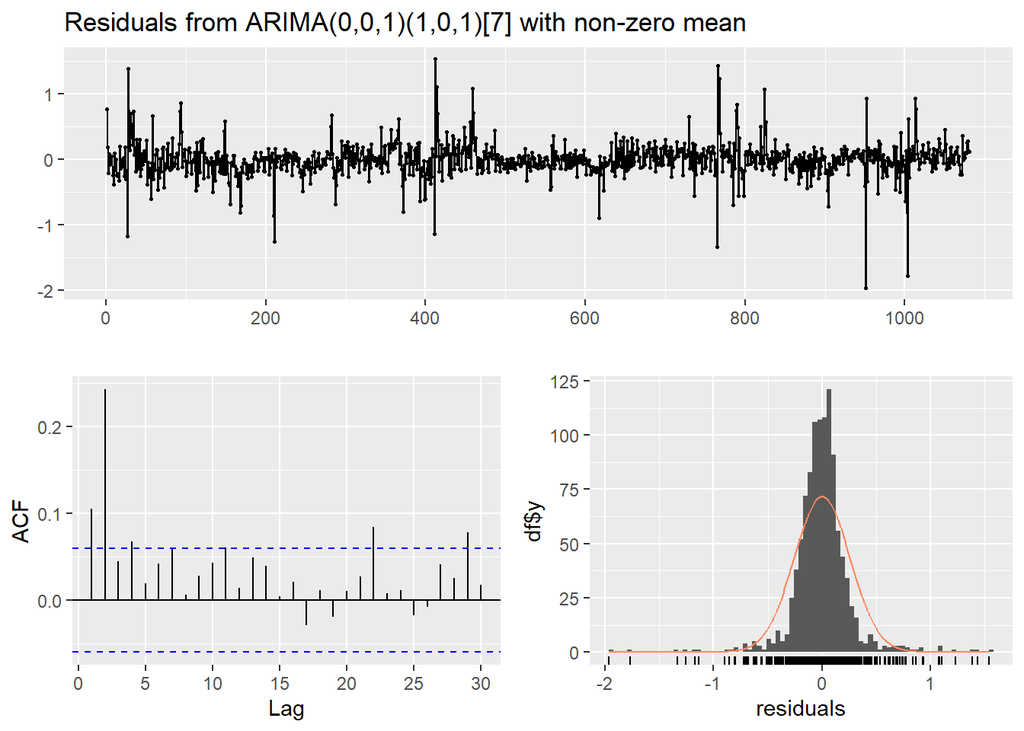

```
##
##  Ljung-Box test
##
## data:  Residuals from ARIMA(0,0,1)(1,0,1)[7] with non-zero mean
## Q* = 92.302, df = 7, p-value < 2.2e-16
##
## Model df: 3.   Total lags used: 10
```

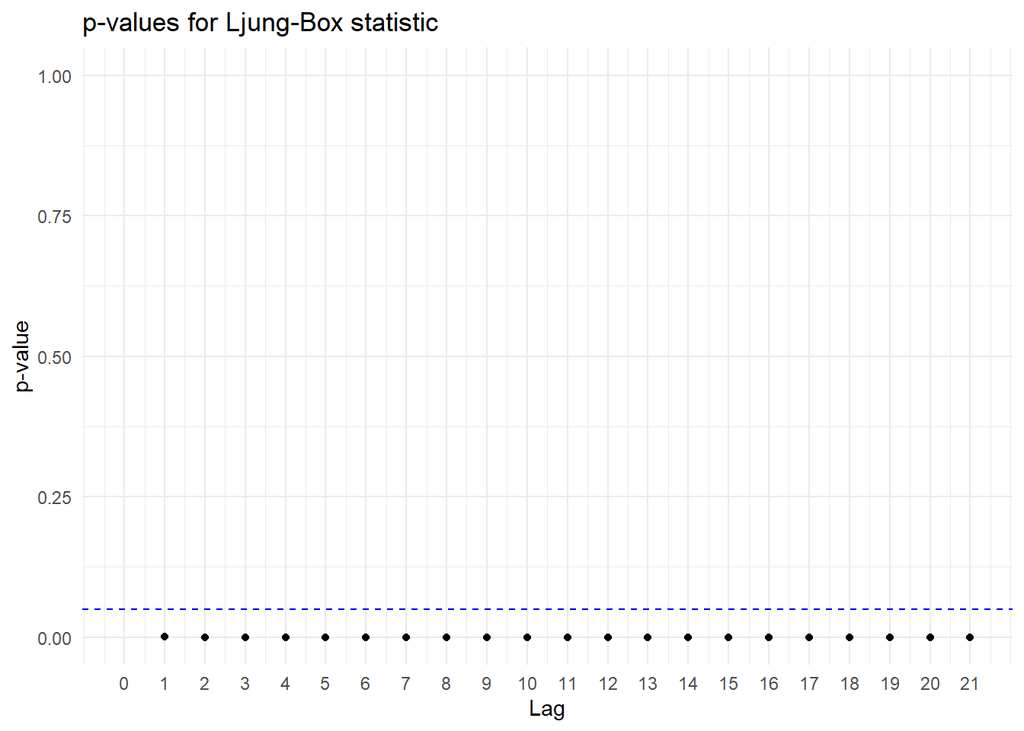

```
##
## Call:
## arima(x = lMRTtrain, order = c(0, 0, 1), seasonal = list(order = c(1, 0, 1),
##     period = 7))
##
## Coefficients:
##          ma1    sar1     sma1  intercept
##       0.4548  0.9989  -0.9716     8.9395
## s.e.  0.0231  0.0010   0.0123     0.0840
##
## sigma^2 estimated as 0.06641:  log likelihood = -75.05,  aic = 160.11
```

模型2

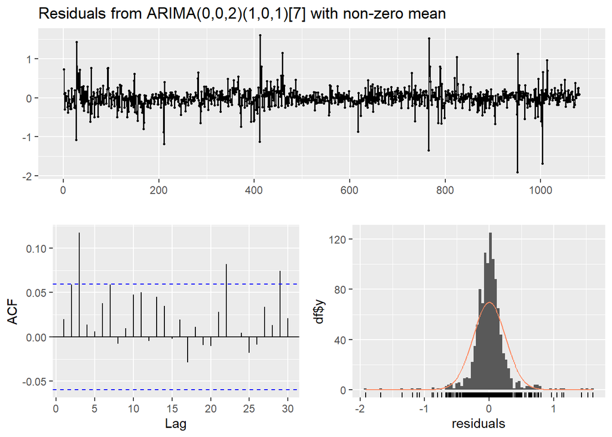

```
##
##  Ljung-Box test
##
## data:  Residuals from ARIMA(0,0,2)(1,0,1)[7] with non-zero mean
## Q* = 27.327, df = 6, p-value = 0.0001258
##
## Model df: 4.   Total lags used: 10
```

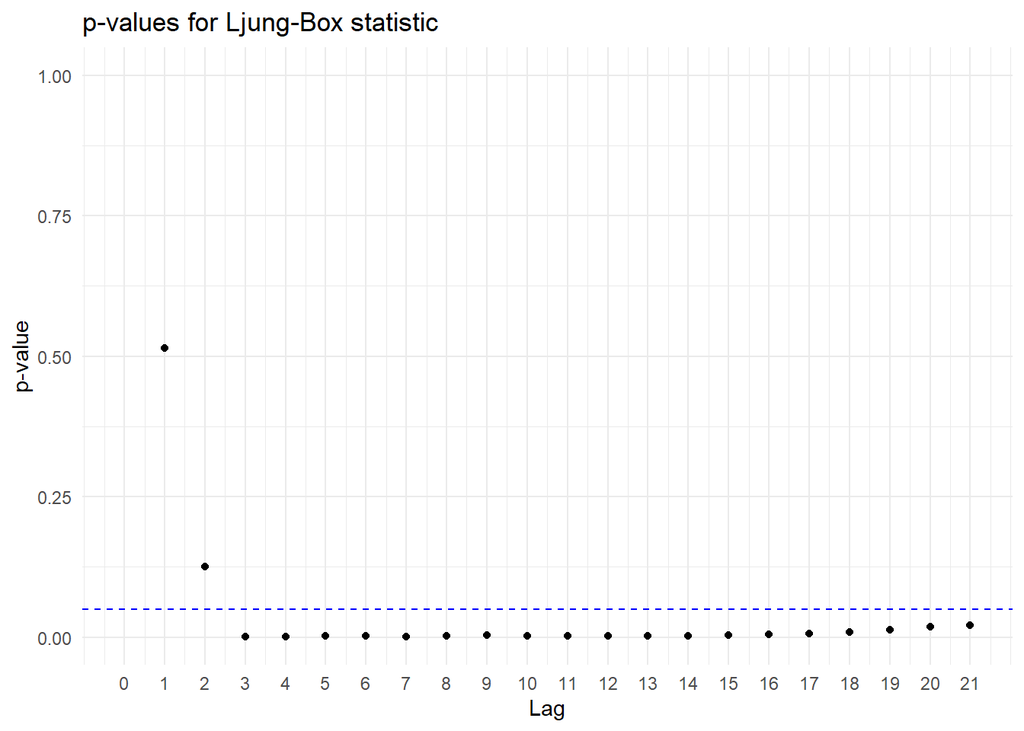

```
##
## Call:
## arima(x = lMRTtrain, order = c(0, 0, 2), seasonal = list(order = c(1, 0, 1),
##     period = 7))
##
## Coefficients:
##          ma1     ma2    sar1     sma1  intercept
##       0.5247  0.2153  0.9992  -0.9730     8.9323
## s.e.  0.0293  0.0276  0.0008   0.0111     0.1074
##
## sigma^2 estimated as 0.06294:  log likelihood = -46.77,  aic = 105.54
```

模型3

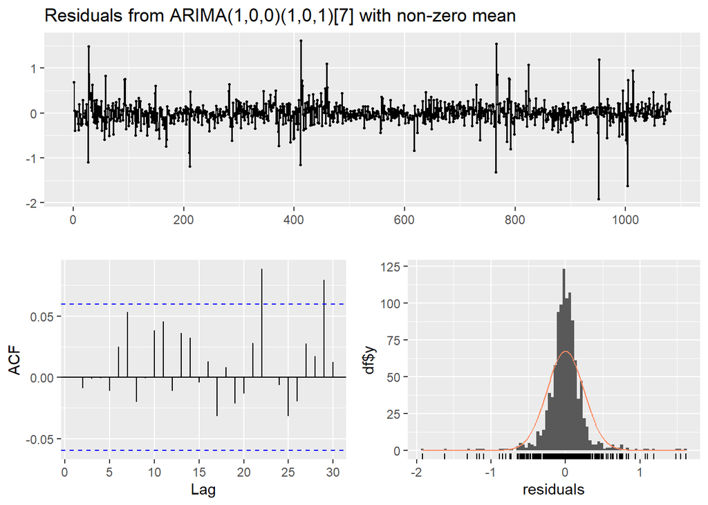

```
##
##  Ljung-Box test
##
## data:  Residuals from ARIMA(1,0,0)(1,0,1)[7] with non-zero mean
## Q* = 6.0182, df = 7, p-value = 0.5376
##
## Model df: 3.   Total lags used: 10
```

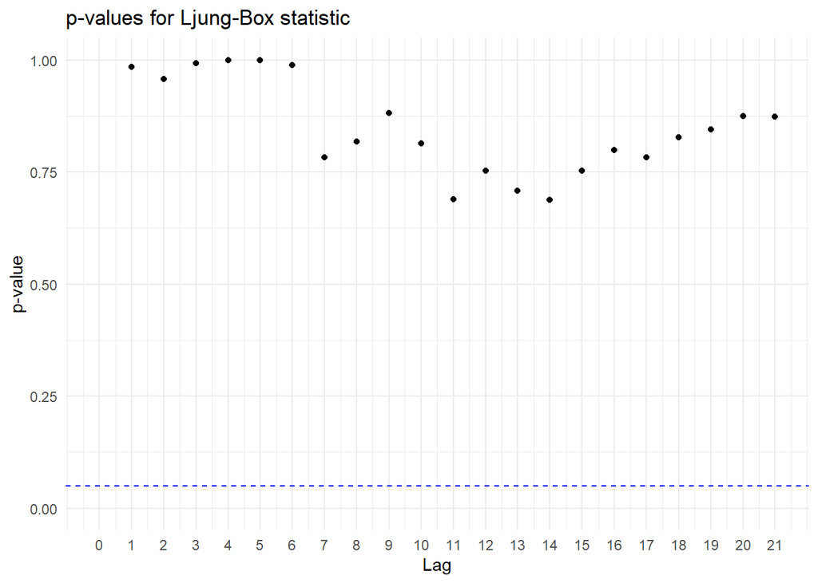

```
##
## Call:
## arima(x = lMRTtrain, order = c(1, 0, 0), seasonal = list(order = c(1, 0, 1),
##     period = 7))
##
## Coefficients:
##          ar1    sar1     sma1  intercept
##       0.5353  0.9992  -0.9730     8.9399
## s.e.  0.0258  0.0007   0.0105     0.1365
##
## sigma^2 estimated as 0.06186:  log likelihood = -37.73,  aic = 85.46
```

結論：

從ACF與Ljung-Box Test圖中可以看出模型3表現最好，殘差之間無明顯的自相關，模型擬合度好。

各模型的log likelihood與AIC整理如下，模型3的log likelihood值最大，AIC最小。因此剔除模型1,2，使用模型3做進一步預測。

|  | 模型1 | 模型2 | 模型3 |
| --- | --- | --- | --- |
| log likelihood | -75.05 | -46.77 | -37.73 |
| AIC | 160.11 | 105.54 | 85.46 |

## 進行預測

最後14期的預測值及95%預測區間：

```
##          Date Lower_95  Forecast Upper_95
## 1  2019-12-18 4824.705  7855.728 12790.93
## 2  2019-12-19 4353.721  7568.374 13156.63
## 3  2019-12-20 4348.871  7692.432 13606.64
## 4  2019-12-21 5693.586 10120.294 17988.73
## 5  2019-12-22 5549.990  9878.789 17583.90
## 6  2019-12-23 3429.437  6106.709 10874.06
## 7  2019-12-24 4163.929  7415.445 13206.00
## 8  2019-12-25 4016.959  7155.934 12747.80
## 9  2019-12-26 4041.217  7199.788 12827.06
## 10 2019-12-27 4203.719  7489.491 13343.54
## 11 2019-12-28 5598.368  9974.319 17770.72
## 12 2019-12-29 5501.321  9801.435 17462.74
## 13 2019-12-30 3414.121  6082.777 10837.39
## 14 2019-12-31 4153.083  7399.351 13183.07
```

從2019年7月20日開始畫時間數列圖，原始資料為黑色線，預測值以紅色線表示，95%預測區間以藍底表示。

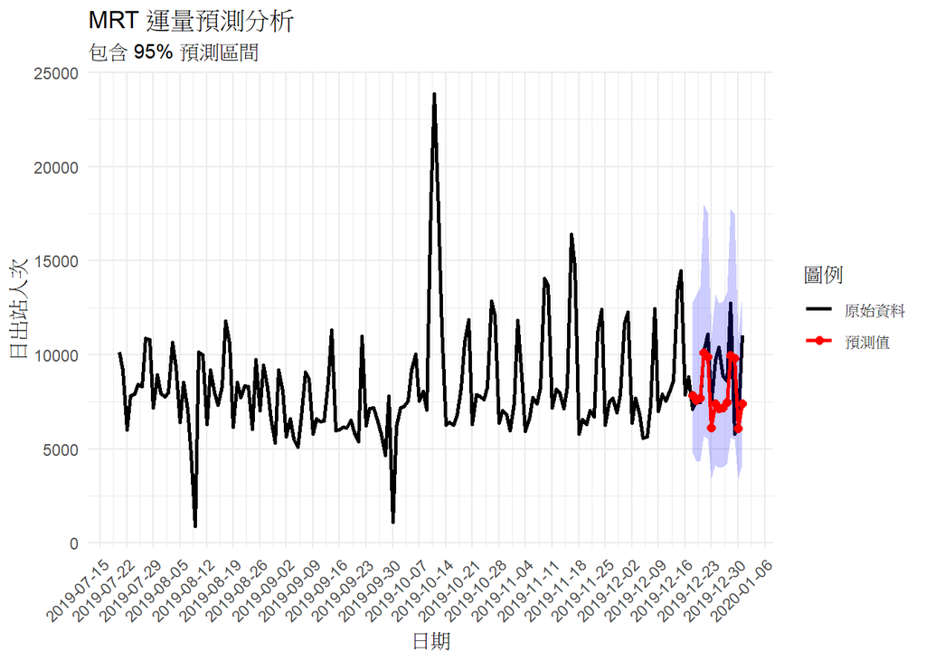

## 結論

1. 由於鄰近動物園與貓空纜車，捷運動物園站成為大眾運輸的重要樞紐之一，透過分析出站人次的歷史資料，可以幫助捷運公司與站務人員預測每日的人流狀況，在尖峰日(如周末及連假)加強⼈流管控或路線指引，預防意外發生。
2. 在基礎設施維護規劃上(如手扶梯或刷卡閘門)，可以在人流量少時，進行日常的維修保養，避免在人潮高峰期進行維修作業而造成動線混亂。
3. 在人流量高的時期(如國慶假期)，可以與動物園合作推出適合親子的系列活動，如闖關活動或特殊造型悠遊卡。此外，分析結果也可以向廣告商證明其廣告價值，作為廣告曝光率的參考資料之一。